# Relatório Municipal de Indicadores 2023

Novo Horizonte do Oeste, Rondônia

SAGICAD e SNAS / MDS

# 1 ID CRAS: Indice de Desenvolvimento do CRAS

O ID CRAS é um indicador composto por três dimensões. Cada dimensão possui uma nota na qual quanto mais próxima de 5, melhor o índice e, do contrário, insatisfatório.

O Gráfico 1 mostra a evolução das médias do ID CRAS ao longo dos anos no município de Novo Horizonte do Oeste, Rondônia.

Gráfico 1. Evolução das médias do ID CRAS, 2014 a 2023: Novo Horizonte do Oeste, Rondônia

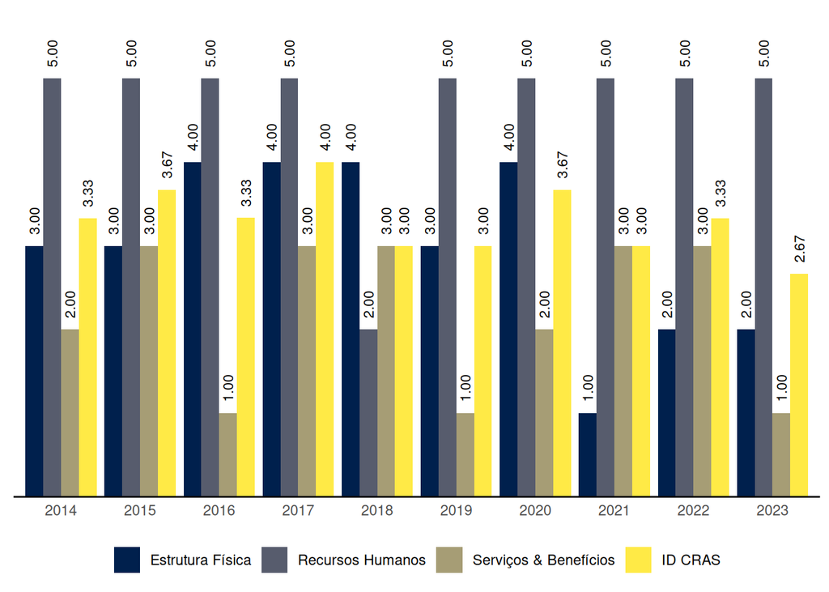

Tabela 1. Quantidade de CRAS em 2023 no município de Novo Horizonte do Oeste por capacidade de referenciamento.

Quantidade de CRAS em 2023 no município de Novo Horizonte do Oeste por capacidade de referenciamento.

| Capacidade de até: | Quantidade |
| --- | --- |
| 2.500 famílias referenciadas | 1 |
| 3.500 famílias referenciadas | 0 |
| 5.000 famílias referenciadas | 0 |

As seções a seguir apresentam os resultados do município de Novo Horizonte do Oeste em cada uma das dimensões do ID CRAS, bem como os requisitos para se alcançar os níveis superiores.

## 1.1 ID CRAS: Dimensão Estrutura Física

### 1.1.1 CRAS com capacidade de referenciamento para até 2.500 ou 3.500 famílias

Na dimensão Estrutura Física, o nível de ID do CRAS com capacidade de referenciamento para até 2.500 ou 3.500 famílias no município de Novo Horizonte do Oeste é 2.

O CRAS de **nível 2**, com capacidade de referenciamento para até 2.500 ou 3.500 famílias, na dimensão Estrutura Física:

- Possui no mínimo **2 salas de atendimento**; e
- Possui pelo menos **1 banheiro**.

Para alcançar o **nível 3** na dimensão Estrutura Física, o CRAS com capacidade de referenciamento para até 2.500 ou 3.500 famílias precisa, além dos requisitos do nível 2:

- Possuir **recepção**; e
- Possuir **acessibiliadade, ao menos parcial**.

### 1.1.2 CRAS com capacidade de referenciamento para até 5.000 famílias

Novo Horizonte do Oeste não tem CRAS com capacidade de referenciamento para até 5.000 famílias.

## 1.2 ID CRAS: Dimensão Recursos Humanos

### 1.2.1 CRAS com capacidade de referenciamento para até 2.500 famílias

Na dimensão Recursos Humanos, o nível de ID do CRAS com capacidade de referenciamento para até 2.500 famílias no município de Novo Horizonte do Oeste é 5.

O CRAS de **nível 5**, com capacidade de referenciamento para até 2.500 famílias, na dimensão Recursos Humanos:

- Possui no mínimo **5** (9, se EV) **profissionais**, sendo pelo menos **3** (5, se EV) com **nível superior**; e
- Possui no mínimo **1 Assistente Social** (2, se EV) e **1 Psicólogo**; e
- Possui no mínimo **1** profissional de nível superior com **vínculo estatutário ou empregado público celetista**; e
- Possui **coordenador** com nível superior.

### 1.2.2 CRAS com capacidade de referenciamento para até 3.500 famílias

Novo Horizonte do Oeste não tem CRAS com capacidade de referenciamento para até 3.500 famílias.

### 1.2.3 CRAS com capacidade de referenciamento para até 5.000 famílias

Novo Horizonte do Oeste não tem CRAS com capacidade de referenciamento para até 5.000 famílias.

## 1.3 ID CRAS: Dimensão Serviços & Benefícios

Na dimensão Serviços & Benefícios, o nível de ID do CRAS no município de Novo Horizonte do Oeste é 1.

O CRAS de **nível 1** na dimensão Serviços & Benefícios em município de porte Pequeno I:

- **Não realiza** alguma(s) das seguintes atividades essenciais do PAIF: **acompanhamento de famílias, e/ou grupo/oficina com famílias, e/ou visitas domiciliares, e/ou orientação**; ou
- Possui **articulação frágil ou inexistente** com os Serviços de Educação e com os Serviços de Saúde; ou
- Não possui profissionais de Serviço Social nem de Psicologia.

Para alcançar o **nível 2** na dimensão Serviços & Benefícios, o CRAS em município de porte Pequeno I precisa:

- **Executar o PAIF**, realizando no mínimo as seguintes atividades: **acompanhamento de famílias, grupo/oficina com famílias e visitas domiciliares**; e
- Possuir **forte articulação com pelo menos um dos seguintes Serviços: Serviços de Educação e Serviços de Saúde**.

# 2 ID CREAS: Indice de Desenvolvimento do CREAS

O ID CREAS é um indicador composto por três dimensões. Cada dimensão possui uma nota na qual quanto mais próxima de 5, melhor o índice e, do contrário, insatisfatório.

Novo Horizonte do Oeste não tem CREAS.

# 3 ID Conselho: Indice de Desenvolvimento dos Conselhos de Assistência Social

O ID Conselho é indicador desenvolvimento com o objetivo de avaliar o controle social no SUAS. Ele possui três dimensões. Cada dimensão possui uma nota na qual quanto mais próxima de 5, melhor o índice e, do contrário, insatisfatório.

O Gráfico 2 mostra a evolução das médias do ID Conselho ao longo dos anos no município de Novo Horizonte do Oeste, Rondônia.

Gráfico 2. Evolução das médias do ID Conselho, 2014 a 2023: Novo Horizonte do Oeste, Rondônia

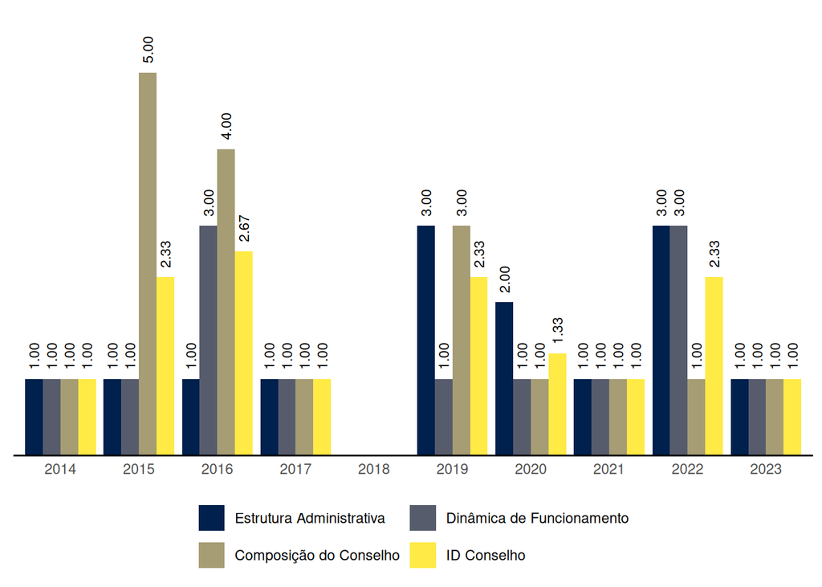

As seções a seguir apresentam os resultados do município de Novo Horizonte do Oeste em cada uma das dimensões do ID Conselho, bem como os requisitos para se alcançar os níveis superiores.

## 3.1 ID Conselho: Dimensão Estrutura Administrativa

Na dimensão Estrutura Administrativa, o nível de ID do Conselho no município de Novo Horizonte do Oeste é 1.

O Conselho de **nível 1** na dimensão Estrutura Administrativa em município de porte Pequeno I:

- **Não** possui previsão de recursos na Lei Orçamentária Anual e **não** utiliza para as despesas de seu funcionamento o mínimo de 3% do IGD; ou
- **Não** possui sala (exclusiva ou compartilhada); ou
- **Não** possui Secretaria Executiva.

Para alcançar o **nível 2** na dimensão Estrutura Administrativa, o Conselho em município de porte Pequeno I precisa:

- Possuir previsão de recursos na Lei Orçamentária Anual ou utilizar para as despesas de seu funcionamento o mínimo de 3% do IGD; e
- Possuir uma ou mais salas de uso exclusivo ou compartilhado; e
- Possuir Secretaria Executiva.

## 3.2 ID Conselho: Dimensão Dinâmica de Funcionamento

Na dimensão Dinâmica de Funcionamento, o nível de ID do Conselho no município de Novo Horizonte do Oeste é 1.

O Conselho de **nível 1** na dimensão Dinâmica de Funcionamento em município de porte Pequeno I:

- **Não** realizou 6 ou mais reuniões plenárias no ano anterior (ordinárias e extraordinárias); ou
- **Não** deliberou sobre o Plano de Assistência Social.

Para alcançar o **nível 2** na dimensão Dinâmica de Funcionamento, o Conselho em município de porte Pequeno I precisa:

- Realizar 6 ou mais reuniões plenárias no ano anterior (ordinárias e extraordinárias); e
- Deliberar sobre o Plano de Assistência Social.

## 3.3 ID Conselho: Dimensão Composição do Conselho

Na dimensão Composição do Conselho, o nível de ID do Conselho no município de Novo Horizonte do Oeste é 1.

O Conselho de **nível 1** na dimensão Composição do Conselho em município de porte Pequeno I:

- Possui menos de 6 conselheiros titulares; ou
- **Não** possui conselheiros titulares representantes de usuários nem de organização de usuários; ou
- **Não** possui alternância na presidência entre os representantes de governo e os representantes da sociedade civil.

Para alcançar o **nível 2** na dimensão Composição do Conselho, o Conselho em município de porte Pequeno I precisa:

- Possuir no mínimo 6 conselheiros titulares; e
- Possuir pelo menos um conselheiro titular representante de usuários ou organização de usuários; e
- Possuir alternância na presidência entre os representantes de governo e os representantes da sociedade civil.